GeoStat Lab · M12 · Raster, telerilevamento e morfometria

M12_N20 · Tessera

# Consegna delle pendenze interne

5 blocchi R eseguiti1 grafico0 errori · 0 avvisiOffline · MathML

Codice, output e figure dello stesso svolgimento. Ogni notebook riparte dai dati locali ed è autonomo rispetto agli altri.

# La domanda

Come si consegnano le 616 pendenze interne mantenendo geometria, orientamento e NoData?

## Obiettivi

- Scrivere e rileggere il CSV originale delle celle interne.
- Esportare GeoTIFF reali con terra.
- Verificare valori, CRS, risoluzione, centri e maschera di bordo.

**Prima di iniziare.** Sono richiesti vettori, matrici, tabelle e funzioni R di base. Eseguire i blocchi in ordine; ogni notebook è autonomo rispetto agli altri. Questo notebook richiede terra installato prima dell’analisi e usa le sue funzioni effettive.

**Dati e unità.** Il raster è interamente sintetico: 24 righe × 30 colonne, 720 celle quadrate di lato 30 m. Nel CSV riga e colonna partono da zero; x_m = 30 × colonna e y_m = 30 × riga indicano i centri nel piano locale. La riga 0 è a Sud; la riga 23 è a Nord. Le quote sono in metri sintetici. I dati non descrivono un rilievo reale. Il GeoTIFF originale porta EPSG:32632, UTM zona 32 Nord, con georeferenziazione fittizia: corner Nord-Ovest E=500000, N=5000000; passo 30 m, PixelIsArea. I centri corrispondono a E=x_m+500015 e N=y_m+4999295. Le righe del TIFF procedono da Nord a Sud, al contrario della matrice locale.

**Relazione usata.** $n_{\mathrm{interni}}=(24-2)(30-2)=616,\qquad n_{\mathrm{bordo}}=720-616=104.$

## Preparazione

Aprire il progetto autonomo di Tessera o quello generale dei notebook. I file originali restano invariati. Gli output vanno in `Risultati/M12_N20/`. Nessun download o installazione avviene nei blocchi.

Codice R · preparazione

```r
# Trova il modulo dal progetto autonomo o da quello generale dei notebook.
.gs_cerca <- normalizePath(getwd(),winslash="/",mustWork=TRUE)
repeat {
  .gs_candidati <- c(.gs_cerca,file.path(.gs_cerca,"M12_Tessera"),
    file.path(.gs_cerca,"03_Notebook_svolti","M12_Tessera"),
    file.path(.gs_cerca,"M12","03_Notebook_svolti","M12_Tessera"))
  .gs_ok <- file.exists(file.path(.gs_candidati,"M12_N01.Rmd")) &
    file.exists(file.path(.gs_candidati,"R","funzioni_notebook.R"))
  if(any(.gs_ok)) { .gs_modulo <- .gs_candidati[which(.gs_ok)[1L]];break }
  .gs_padre <- dirname(.gs_cerca)
  if(.gs_padre==.gs_cerca) stop("Aprire il progetto M12_Tessera o quello generale dei notebook.")
  .gs_cerca <- .gs_padre
}
source(file.path(.gs_modulo,"R","funzioni_notebook.R"),local=TRUE)
.gs_funzioni <- .gs_prepara_notebook(.gs_modulo,"M12_N20")
carica_dati <- .gs_funzioni$carica_dati
percorso_dati <- .gs_funzioni$percorso_dati
percorso_risultati <- .gs_funzioni$percorso_risultati
options(width=88,digits=6)
if(requireNamespace("knitr",quietly=TRUE)) {
  knitr::opts_chunk$set(echo=TRUE,error=FALSE,warning=TRUE,message=TRUE,
    fig.width=8,fig.height=5,dpi=150,fig.align="center")
}
set.seed(20261104)
```

## 1. Il CSV mantiene le coordinate delle celle interne

La differenza centrale esclude una fascia di una cella su ciascun lato. I 616 valori sono ordinati da Sud a Nord nel CSV.

Codice R · passo_01

```r
d <- carica_dati("raster_v3.csv")
audit_raster(d)
d <- d[order(d$riga,d$colonna),]
Z <- matrice_quote(d)
richiedi_terra()
r <- terra::rast(percorso_dati("raster_v3.tif"))
 g <- gradienti_centrali(Z);s <- g$gradi
 risultato <- data.frame(x_m=rep((1:28)*30,22),y_m=rep((1:22)*30,each=28),
   pendenza_gradi=as.vector(t(s)))
 file_csv <- percorso_risultati("pendenze.csv")
 write.csv(risultato,file_csv,row.names=FALSE)
 csv_letto <- read.csv(file_csv)
 data.frame(celle=nrow(csv_letto),minimo=min(csv_letto$pendenza_gradi),
   massimo=max(csv_letto$pendenza_gradi),errore_roundtrip=max(abs(csv_letto$pendenza_gradi-risultato$pendenza_gradi)))
 stopifnot(nrow(csv_letto)==616L,all(is.finite(csv_letto$pendenza_gradi)),
   max(abs(csv_letto$pendenza_gradi-risultato$pendenza_gradi))<1e-10)
```

Output eseguito

```
  celle   minimo massimo errore_roundtrip
1   616 0.487566 28.5294       4.9738e-14
```

**Lettura del risultato.** Le coordinate interne sono x=30…840 m e y=30…660 m. Le quote originarie e le pendenze hanno unità differenti.

## 2. Due GeoTIFF esplicitano il bordo

Il file principale è 22 × 28, ristretto alle celle interne. Il secondo conserva 24 × 30 celle, con 104 celle di bordo NoData. I valori sono materializzati prima della scrittura.

Codice R · passo_02

```r
completo <- matrix(NA_real_,24,30);completo[2:23,2:29] <- s
r_completo <- raster_da_matrice(completo,r);names(r_completo) <- "pendenza_gradi"
modello_interno <- terra::crop(terra::rast(r),terra::ext(500030,500870,4999310,4999970))
r_interno <- raster_da_matrice(s,modello_interno);names(r_interno) <- "pendenza_gradi"
file_interno <- percorso_risultati("pendenze_interne.tif")
file_bordo <- percorso_risultati("pendenze_con_bordo_NoData.tif")
terra::writeRaster(r_interno,file_interno,overwrite=TRUE,datatype="FLT8S",NAflag=-9999,gdal="COMPRESS=NONE")
terra::writeRaster(r_completo,file_bordo,overwrite=TRUE,datatype="FLT8S",NAflag=-9999,gdal="COMPRESS=NONE")
data.frame(file=c(basename(file_interno),basename(file_bordo)),
  righe=c(nrow(r_interno),nrow(r_completo)),colonne=c(ncol(r_interno),ncol(r_completo)),
  celle_valide=c(sum(is.finite(s)),sum(is.finite(completo))),
  celle_NoData=c(sum(is.na(s)),sum(is.na(completo))))
```

Output eseguito

```
                           file righe colonne celle_valide celle_NoData
1          pendenze_interne.tif    22      28          616            0
2 pendenze_con_bordo_NoData.tif    24      30          616          104
```

**Lettura del risultato.** La georeferenziazione fittizia viene ereditata senza attribuirle realtà geografica. Nel TIFF le righe sono ribaltate rispetto al CSV; il valore NoData scritto è −9999, distinto da una pendenza nulla.

## 3. Rilettura e verifica cella per cella

Riapriamo entrambi i file con terra. Il controllo riguarda geometria, centro di riferimento, orientamento, maschera e valori.

Codice R · passo_03

```r
letto <- terra::rast(file_interno);bordo <- terra::rast(file_bordo)
valori <- matrice_locale(letto);valori_bordo <- matrice_locale(bordo)
centri <- terra::xyFromCell(letto,c(1,terra::ncell(letto)))
audit <- data.frame(controllo=c("Geometria interna","Geometria completa","Risoluzione 30m",
  "616 valori interni","104 NoData bordo","Maschera esatta","Valori interni","Valori completi",
  "Centro NW corretto","Centro SE corretto"),
  esito=c(terra::compareGeom(letto,r_interno,stopOnError=FALSE),
    terra::compareGeom(bordo,r,stopOnError=FALSE),all(terra::res(letto)==30),
    sum(is.finite(valori))==616L,sum(is.na(valori_bordo))==104L,
    identical(is.na(valori_bordo),is.na(completo)),max(abs(valori-s))<1e-10,
    max(abs(valori_bordo-completo),na.rm=TRUE)<1e-10,
    max(abs(centri[1,]-c(500045,4999955)))<1e-9,
    max(abs(centri[2,]-c(500855,4999325)))<1e-9))
audit
stopifnot(all(audit$esito))
crs_letto <- terra::crs(letto,describe=TRUE)[,c("name","authority","code")]
crs_letto
info_interno <- terra::describe(file_interno,print=FALSE)
info_bordo <- terra::describe(file_bordo,print=FALSE)
tag_NoData <- data.frame(file=c(basename(file_interno),basename(file_bordo)),
  sentinel_meno9999=c(any(grepl("NoData Value=-9999",info_interno,fixed=TRUE)),
    any(grepl("NoData Value=-9999",info_bordo,fixed=TRUE))))
tag_NoData
stopifnot(all(as.character(crs_letto$code)=="32632"),all(tag_NoData$sentinel_meno9999))
writeLines(info_interno,percorso_risultati("GDAL_pendenze_interne.txt"))
writeLines(info_bordo,percorso_risultati("GDAL_pendenze_con_bordo.txt"))
write.csv(tag_NoData,percorso_risultati("audit_tag_NoData.csv"),row.names=FALSE)
write.csv(audit,percorso_risultati("audit_consegna.csv"),row.names=FALSE)
writeLines(c("DATI SINTETICI; georeferenziazione UTM fittizia EPSG32632.",
  "CSV: 616 centri locali, righe da Sud a Nord, pendenza in gradi.",
  "GeoTIFF interno: 22x28, passo 30 m, corner NW 500030/4999970.",
  "GeoTIFF completo: 24x30, 104 celle di bordo NoData; NAflag=-9999, FLT8S.",
  "Centri: E=x_locale+500015, N=y_locale+4999295. TIFF da Nord a Sud.",
  paste("terra",packageVersion("terra"))),percorso_risultati("scheda_consegna.txt"))
mappa_matrice(valori,(1:28)*30,(1:22)*30,titolo="Pendenze GeoTIFF rilette: 616 celle",unita="Gradi")
```

Output eseguito

```
            controllo esito
1   Geometria interna  TRUE
2  Geometria completa  TRUE
3     Risoluzione 30m  TRUE
4  616 valori interni  TRUE
5    104 NoData bordo  TRUE
6     Maschera esatta  TRUE
7      Valori interni  TRUE
8     Valori completi  TRUE
9  Centro NW corretto  TRUE
10 Centro SE corretto  TRUE
                   name authority  code
1 WGS 84 / UTM zone 32N      EPSG 32632
                           file sentinel_meno9999
1          pendenze_interne.tif              TRUE
2 pendenze_con_bordo_NoData.tif              TRUE
```

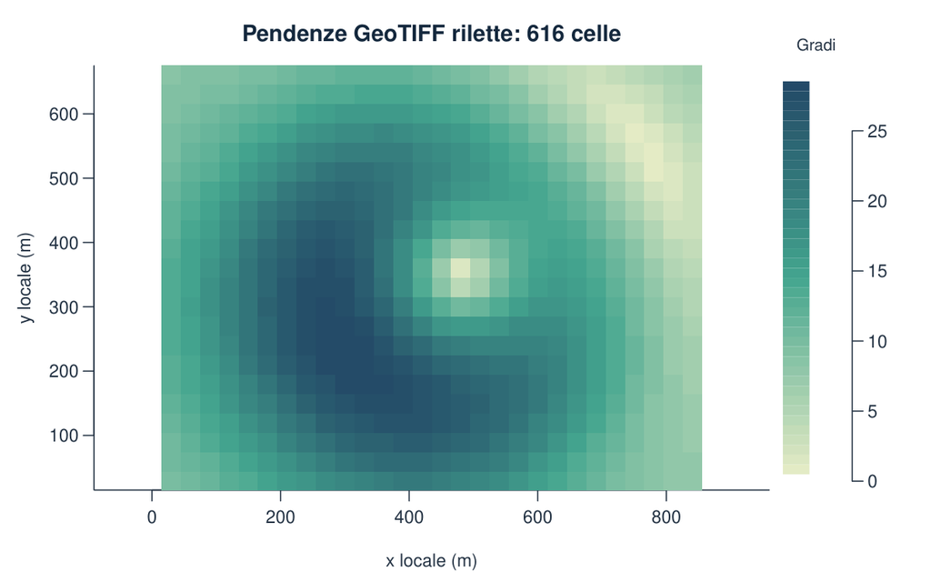

Figura 1 · Output del blocco `passo_03`. PDF vettoriale.

**Lettura del risultato.** Un file che si apre non è necessariamente corretto. La verifica deve includere il CRS, non soltanto forma e valori; compareGeom controlla anche il riferimento geografico dei file prodotti.

## Variante svolta

**L’errore di orientamento conserva media e istogramma.** Confrontare la matrice terra senza ribaltamento con la matrice locale e verificare che la media non lo riconosca.

Codice R · variante

```r
sbagliata <- terra::as.matrix(letto,wide=TRUE)
data.frame(scarto_senza_ribaltamento=max(abs(sbagliata-s)),
  media_invariata=abs(mean(sbagliata)-mean(s))<1e-10,
  scarto_corretto=max(abs(sbagliata[nrow(sbagliata):1,]-s)))
stopifnot(max(abs(sbagliata-s))>0)
```

Output eseguito

```
  scarto_senza_ribaltamento media_invariata scarto_corretto
1                   10.4675            TRUE               0
```

La consegna corretta mantiene la corrispondenza cella per cella. I controlli del solo range, della media o del numero di celle non bastano.

## Errore da riconoscere

Consegnare soltanto una matrice senza georeferenziazione, confondere bordo NoData con pendenza zero o dimenticare il ribaltamento Nord-Sud.

## Risposta alla domanda

La consegna comprende CSV, GeoTIFF interno, GeoTIFF con bordo NoData e una scheda. La rilettura reale con terra verifica 616 pendenze, 104 celle di bordo assenti, orientamento e geometria fittizia dichiarata.

## Raccordo con le slide

Slide 106–108 della lezione Tessera. La mappa dei notebook e delle slide conserva il raccordo puntuale con la lezione estesa.

## Riferimenti e provenienza

Questo svolgimento sviluppa `M12_N20` del [modulo M12 del corso](https://marzione00.github.io/Lab_Geo/#modulo-M12). Il [codice originale](https://github.com/marzione00/Lab_Geo/blob/649f7cc577b96bd1044d81e78a2f530813e4f96b/materiali/laboratori/M12/M12_N20.R) è conservato immutato in `R/Originali_corso/`. Dati e originali hanno SHA-256 e SHA-1 Git verificati; gli ampliamenti sono dichiarati nella mappa degli originali.

Documentazione primaria: [terra, rast](https://rspatial.github.io/terra/reference/rast.html), [terra, resample](https://rspatial.github.io/terra/reference/resample.html), [terra, readValues](https://rspatial.github.io/terra/reference/readValues.html), [terra, writeRaster](https://rspatial.github.io/terra/reference/writeRaster.html).